```python
import pandas as pd
import numpy as np
import random
import math as m
import matplotlib.pyplot as plt
import statistics as s
random.seed(1)
```

# Assignment 1

### Part 1

```python
a = pd.DataFrame()
for i in range(0,15):
    a[i] = (2*np.random.random_sample(size = 1000))-1;

#print(a)
```

# I created a matrix with 1000 rows and 15 columns

```python
res = (a.apply(abs,axis= 1).apply(np.square,axis = 1).cumsum(axis = 1)**(1/2) <= 1).sum()/1000
```

```python
xx = range(15)
```

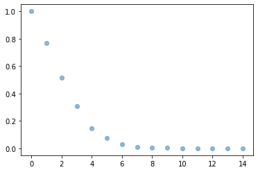

```python
plt.scatter(xx, res, alpha=0.5)
plt.show()
```

B)

The area of a circle and the corresponding square in 2-D is A_circle = pi*r^2 A_square = 4*r^2 as one side of the square is 2 units

```python
A_square = 4*(1**2)
```

```python
A_circle = (m.pi)*(1**2)
```

```python
A_circle / A_square
```

```
0.7853981633974483
```

```python
res[1]
```

```
0.766
```

The true value of the fraction in 2-D is around 78.5% and our approximation yields 76.6%. Let us estimate the value of pi from our approximation

```python
pi_true = 4*A_circle/A_square
```

```python
pi_appr = 4*res[1]
```

```python
pi_appr
```

```
3.064
```

We see that our pi approximation is 3.064 while the true value is around 3.14

Let us see the case in 3-D

```python
V_cube = 8*(1**3)
V_sphere = 4*m.pi*(1**3)/3
```

```python
V_sphere / V_cube
```

```
0.5235987755982988
```

```python
res[2]
```

```
0.517
```

```python
pi_true = (V_sphere/V_cube)*6
```

```python
pi_true
```

```
3.141592653589793
```

```python
pi_appr = res[2]*6
```

```python
pi_appr
```

```
3.1020000000000003
```

We see that our pi approximation is 3.102 while the true value is around 3.14

C)

```python
def estimator(sample_size):
    a = pd.DataFrame()
    for i in range(0,15):
        a[i] = (2*np.random.random_sample(size = 1000))-1;
    res = (a.apply(abs,axis= 1).apply(np.square,axis = 1).cumsum(axis = 1)**(1/2) <= 1).sum()/1000
    xx = range(15)
    plt.scatter(xx, res, alpha=0.5)
    plt.show()
    return res, print('2-D Estimation of pi is:', res[1]*4, 'and 3-D Estimation of pi is:', res[2]*6 )
```

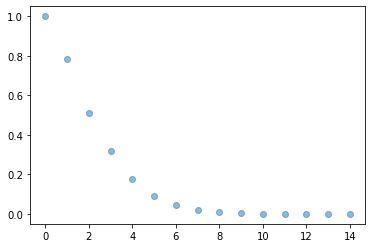

```
2-D Estimation of pi is: 3.144 and 3-D Estimation of pi is: 3.072
```

```
(0     1.000
 1     0.786
 2     0.512
 3     0.317
 4     0.179
 5     0.093
 6     0.043
 7     0.019
 8     0.010
 9     0.003
 10    0.001
 11    0.000
 12    0.000
 13    0.000
 14    0.000
 dtype: float64,
 None)
```

```python
estimator(5000)
```

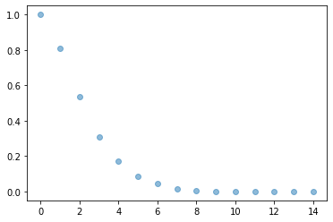

```
2-D Estimation of pi is: 3.232 and 3-D Estimation of pi is: 3.204
```

```
(0     1.000
 1     0.808
 2     0.534
 3     0.307
 4     0.173
 5     0.085
 6     0.045
 7     0.016
 8     0.005
 9     0.001
 10    0.001
 11    0.001
 12    0.000
 13    0.000
 14    0.000
 dtype: float64,
 None)
```

```python
estimator(10000)
```

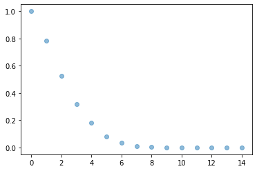

```
2-D Estimation of pi is: 3.14 and 3-D Estimation of pi is: 3.162
```

```
(0     1.000
 1     0.785
 2     0.527
 3     0.319
 4     0.180
 5     0.082
 6     0.035
 7     0.010
 8     0.005
 9     0.001
 10    0.001
 11    0.000
 12    0.000
 13    0.000
 14    0.000
 dtype: float64,
 None)
```

```python
estimator(25000)
```

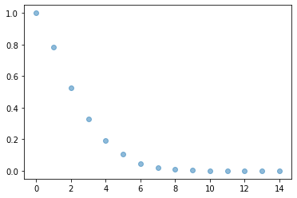

```
2-D Estimation of pi is: 3.136 and 3-D Estimation of pi is: 3.162
```

```
(0     1.000
 1     0.784
 2     0.527
 3     0.328
 4     0.193
 5     0.108
 6     0.047
 7     0.022
 8     0.010
 9     0.004
 10    0.000
 11    0.000
 12    0.000
 13    0.000
 14    0.000
 dtype: float64,
 None)
```

```python
estimator(50000)
```

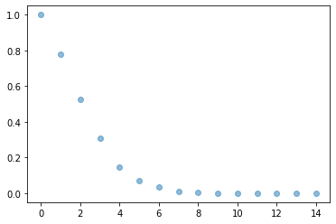

```
2-D Estimation of pi is: 3.116 and 3-D Estimation of pi is: 3.168
```

```
(0     1.000
 1     0.779
 2     0.528
 3     0.306
 4     0.147
 5     0.072
 6     0.036
 7     0.011
 8     0.005
 9     0.002
 10    0.001
 11    0.000
 12    0.000
 13    0.000
 14    0.000
 dtype: float64,
 None)
```

```python
estimator(100000)
```

[output not shown]

D)

```python
random.seed(1881)
```

```python
a = pd.DataFrame()
for i in range(0,15):
    a[i] = (2*np.random.random_sample(size = 1000))-1;
```

```python
test = pd.DataFrame()
for i in range(0,15):
    test[i] = (2*np.random.random_sample(size = 100))-1;
```

```python
dist = pd.DataFrame()
for i in range(0,15):
    for j in range(0,100):
        dist.at[j, i] = min((((test.iloc[j].iloc[0:i+1]-a.iloc[:, 0:i+1])**2).apply(sum,axis= 1))**(1/2))
```

```python
avgdist = dist.apply(s.mean,axis = 0)
```

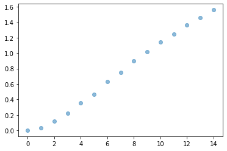

```python
xx = range(15)
plt.scatter(xx, avgdist, alpha=0.5)
plt.show()
```

### Part 2

```python
import matplotlib as mpl
import matplotlib.pyplot as plt
```

A)

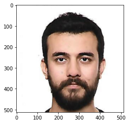

```python
image = mpl.pyplot.imread('vesikalik_hw.jpg')


plt.imshow(image)
```

```python
image.shape
```

```
(512, 512, 3)
```

B)

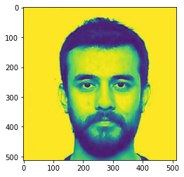

```python
plt.imshow(image[:,:,0])
```

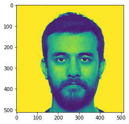

```python
plt.imshow(image[:,:,1])
```

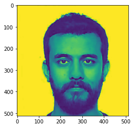

```python
plt.imshow(image[:,:,2])
```

C)

```python
channel1 = pd.DataFrame(image[:,:,0])
channel2 = pd.DataFrame(image[:,:,1])
channel3 = pd.DataFrame(image[:,:,2])
```

```python
channel1.apply(s.mean, axis = 0)
```

```
0      255.000000
1      254.994141
2      254.984375
3      254.927734
4      254.919922
          ...
507    255.000000
508    255.000000
509    255.000000
510    255.000000
511    255.000000
Length: 512, dtype: float64
```

```python
channel2.apply(s.mean, axis = 0)
```

```
0      255.000000
1      254.994141
2      254.984375
3      254.927734
4      254.919922
          ...
507    255.000000
508    255.000000
509    255.000000
510    255.000000
511    255.000000
Length: 512, dtype: float64
```

```python
channel3.apply(s.mean, axis = 0)
```

```
0      255.000000
1      254.994141
2      254.984375
3      254.927734
4      254.919922
          ...
507    255.000000
508    255.000000
509    255.000000
510    255.000000
511    255.000000
Length: 512, dtype: float64
```

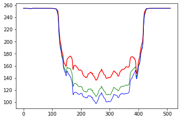

```python
plt.plot(range(0,512),channel1.apply(s.mean, axis = 0),color='red')
plt.plot(range(0,512), channel2.apply(s.mean, axis = 0),
         color='green',
         linewidth=1.0
        )
plt.plot(range(0,512), channel3.apply(s.mean, axis = 0),
         color='blue',
         linewidth=1.0
        )
```

D)

Here, subtracting the halves in reverse order makes more sense to me, as I consider the symmetric images in two sides

```python
new_image = np.empty((512,256,3))
for i in range(0,3):
    new_image[:,:,i] = image[:,0:256,i]-image[:,512:255:-1,i]
```

```python
new_image = new_image.clip(min=0)
```

```
Clipping input data to the valid range for imshow with RGB data ([0..1] for floats or [0..255] for integers).
```

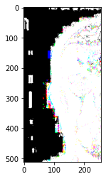

```python
plt.imshow(new_image)
```

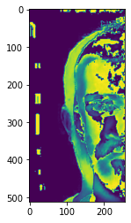

```python
plt.imshow(new_image[:,:,0])
```

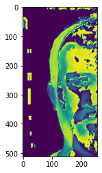

```python
plt.imshow(new_image[:,:,1])
```

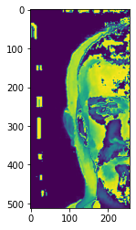

```python
plt.imshow(new_image[:,:,2])
```

E) Here, I add a random noise as described, however since the colour scale is 0-256 in my format, I encountered that values higher than 255 are displayed as white in the image, therefore, I decided to apply modulo function to the formatted pixels so that new values remains in the defined range

```python
noisy_image = np.empty((512,512,3))
for i in range(0,512):
    for j in range(0,512):
        noisy_image[i,j,0] = np.around(image[i,j,0] + 0.1 * np.random.random_sample(size = 1)*image[:,:,0].max())%256
        noisy_image[i,j,1] = np.around(image[i,j,1] + 0.1 * np.random.random_sample(size = 1)*image[:,:,1].max())%256
        noisy_image[i,j,2] = np.around(image[i,j,2] + 0.1 * np.random.random_sample(size = 1)*image[:,:,2].max())%256
```

```
Clipping input data to the valid range for imshow with RGB data ([0..1] for floats or [0..255] for integers).
```

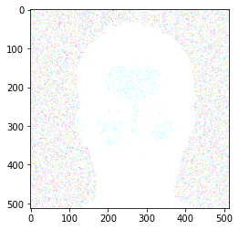

```python
plt.imshow(noisy_image)
```

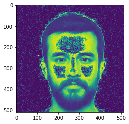

```python
plt.imshow(noisy_image[:,:,0])
```

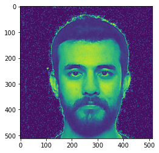

```python
plt.imshow(noisy_image[:,:,1])
```

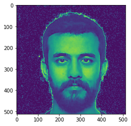

```python
plt.imshow(noisy_image[:,:,2])
```